# Modelagem do Prêmio frequência-severidade por Bullman-Straub, Random Forest e XGboost com grupos tarifários agrupados por experiência do analista

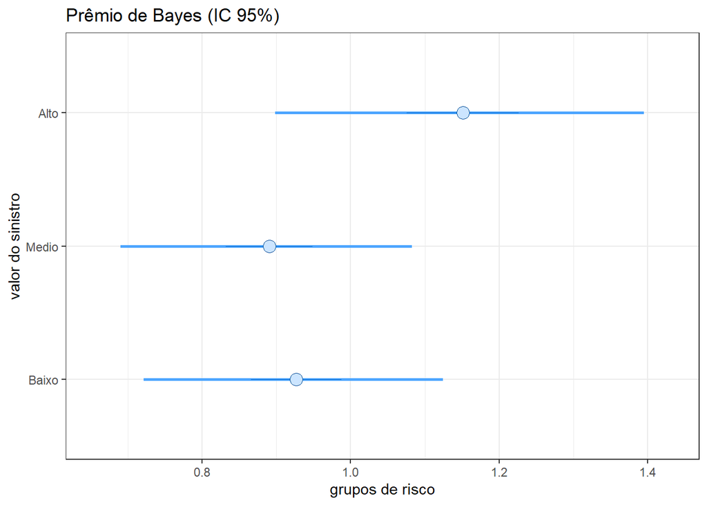

```r
### estimativa pontual a posteriori e intervalo de credibilidade
color_scheme_set("brightblue")
mcmc_intervals(theta.s, point_est="mean", inner_size=0.025, outer_size=0.975) + theme_bw() +
  labs(x = "grupos de risco", y = "valor do sinistro", title = "Prêmio de Bayes (IC 95%)") +
  geom_point(aes(x=summary.post$Pbayes,y=3:1), col="lightgreen", size=3)
```

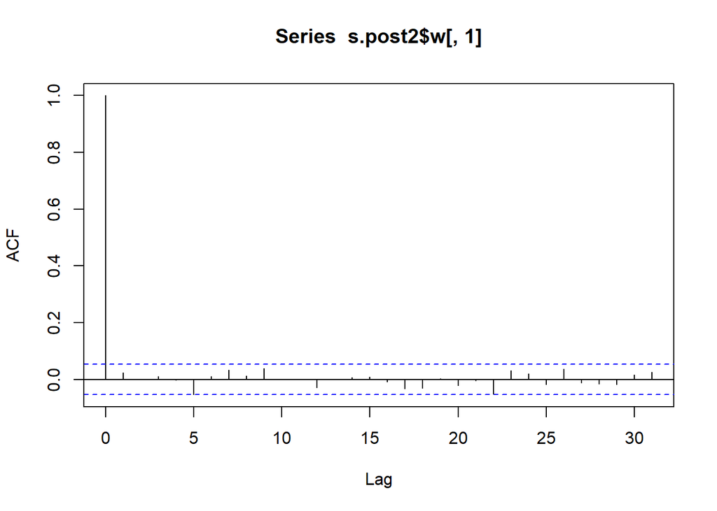

```r
### autocorrelacao das cadeias
acf(s.post2$w[,1])
```

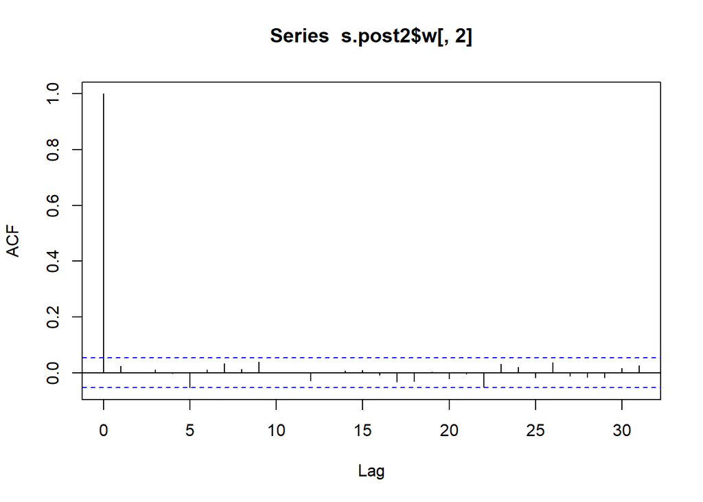

```r
acf(s.post2$w[,2])
```

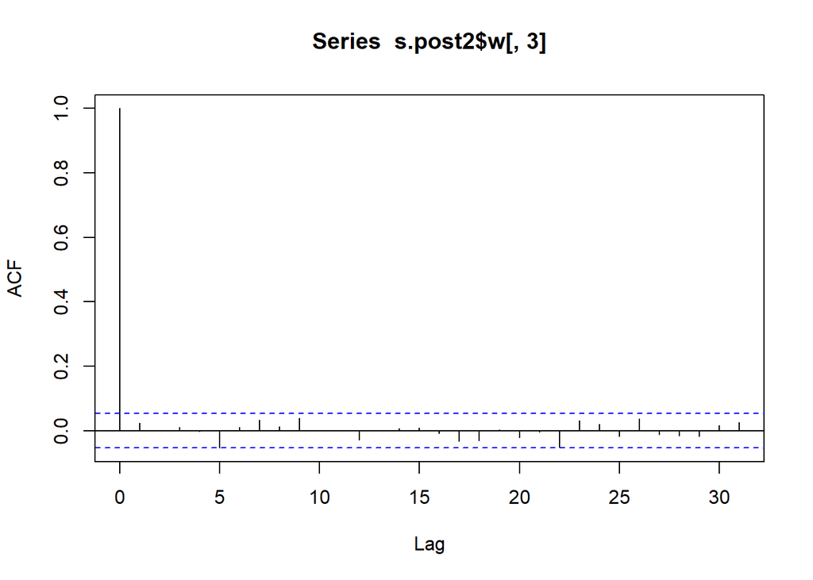

```r
acf(s.post2$w[,3])
```

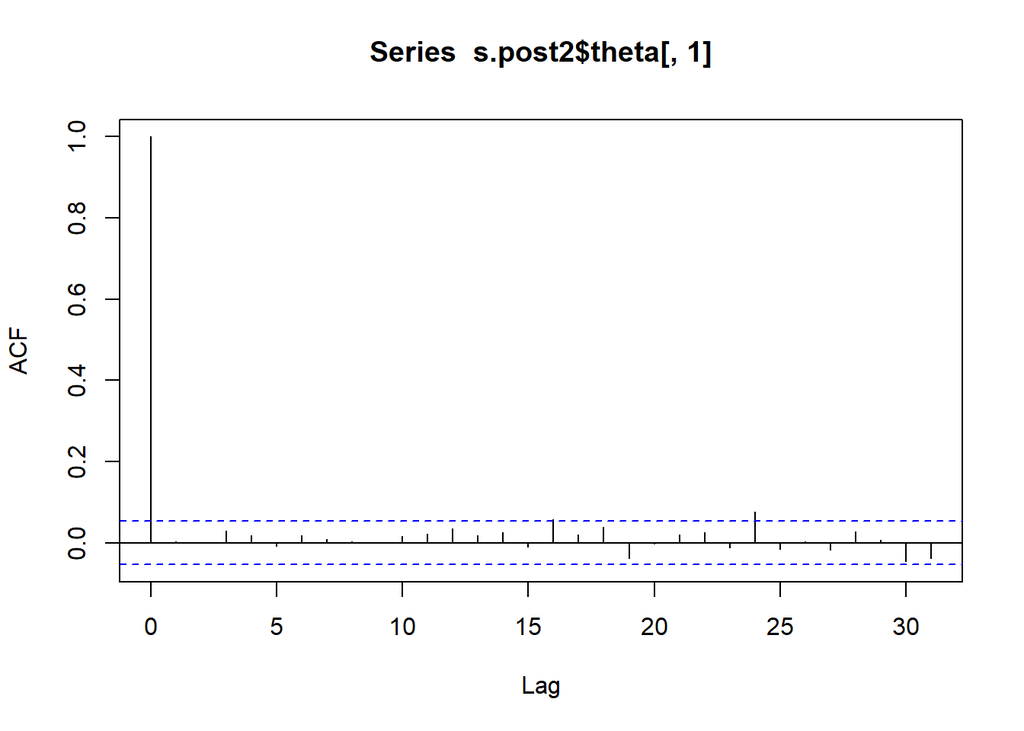

```r
acf(s.post2$theta[,1])
```

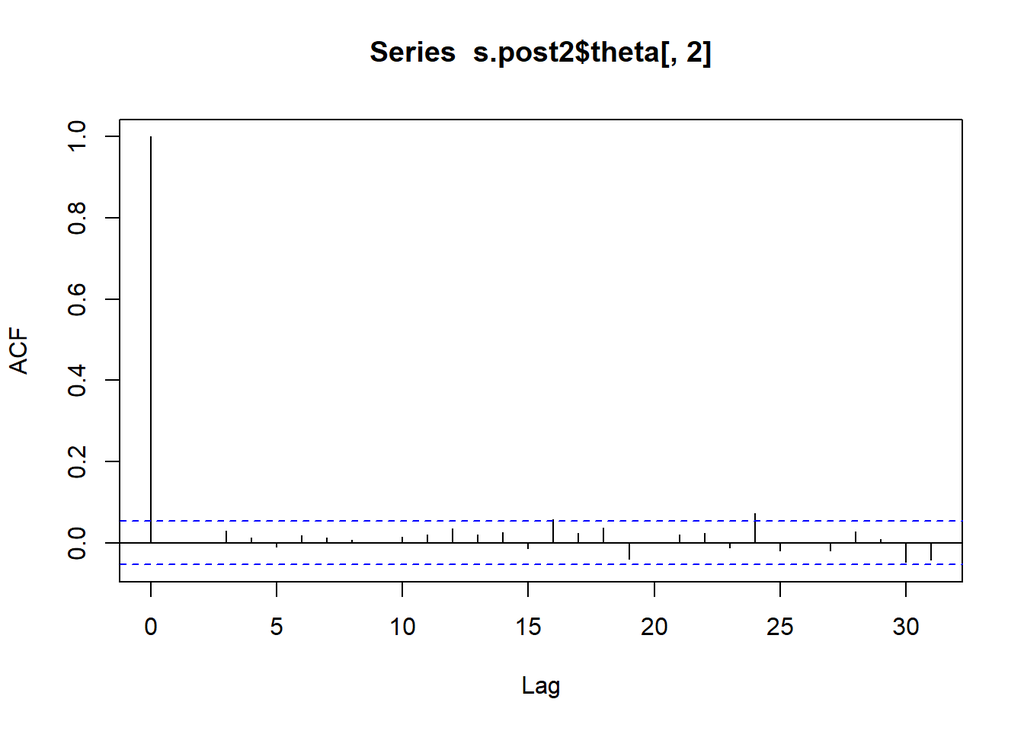

```r
acf(s.post2$theta[,2])
```

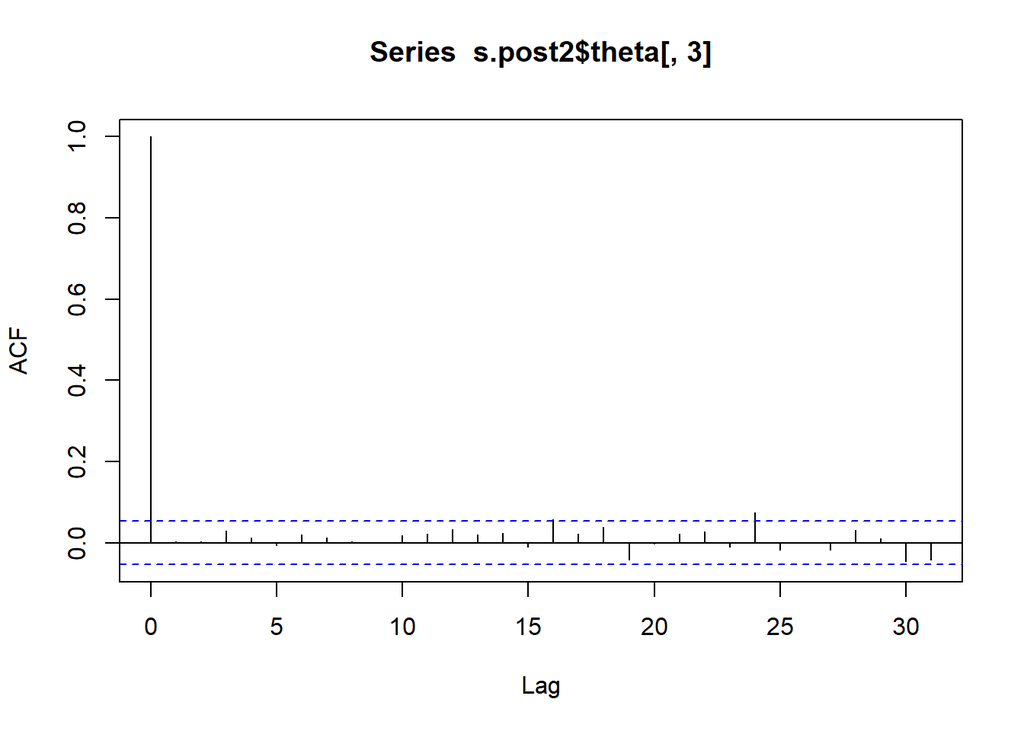

```r
acf(s.post2$theta[,3])
```

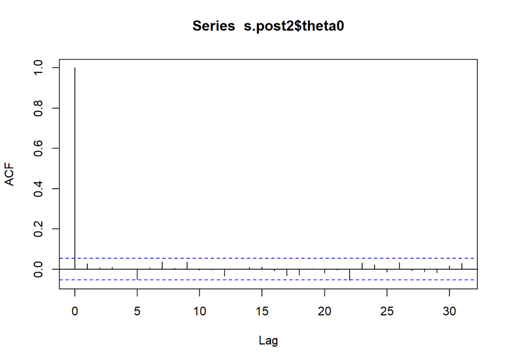

```r
acf(s.post2$theta0)
```

```r
### estimativa pontual
summary(s.post2$w[,1])  ### Pcred.1 bayes
```

```
##    Min. 1st Qu.  Median    Mean 3rd Qu.    Max.
##  0.9832  0.9972  0.9986  0.9980  0.9994  1.0000
```

```r
summary(s.post2$w[,2])  ### Pcred.2 bayes
```

```
##    Min. 1st Qu.  Median    Mean 3rd Qu.    Max.
##  0.9871  0.9979  0.9989  0.9985  0.9995  1.0000
```

```r
summary(s.post2$w[,3])  ### Pcred.3 bayes
```

```
##    Min. 1st Qu.  Median    Mean 3rd Qu.    Max.
##  0.9911  0.9985  0.9993  0.9990  0.9997  1.0000
```

```r
summary(s.post2$theta[,1])
```

```
##    Min. 1st Qu.  Median    Mean 3rd Qu.    Max.
##  0.1709  1.0754  1.1533  1.1512  1.2263  2.3836
```

```r
summary(s.post2$theta[,2])
```

```
##    Min. 1st Qu.  Median    Mean 3rd Qu.    Max.
##  0.1311  0.8319  0.8925  0.8910  0.9487  1.8387
```

```r
summary(s.post2$theta[,3])
```

```
##    Min. 1st Qu.  Median    Mean 3rd Qu.    Max.
##  0.1361  0.8659  0.9285  0.9270  0.9876  1.8993
```

```r
summary(s.post2$theta0)
```

```
##     Min.  1st Qu.   Median     Mean  3rd Qu.     Max.
##   0.3555  15.3347  35.2371  50.6446  69.5184 420.6224
```

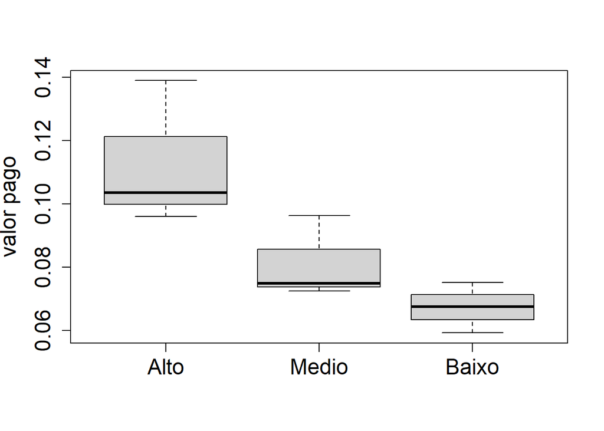

```r
boxplot(t(M3), ylab="valor pago", cex=1.5, cex.lab=1.5,cex.axis=1.5)
```

```r
# calculando os prêmios de credibilidade e premio individual para frequência

Pcred1_freq = (s.post2$lambda0) *  (s.post2$theta[,1])
Pcred2_freq = (s.post2$lambda0) *  (s.post2$theta[,2])
Pcred3_freq = (s.post2$lambda0) *  (s.post2$theta[,3])

summary(Pcred1_freq)
```

```
##    Min. 1st Qu.  Median    Mean 3rd Qu.    Max.
## 0.09172 0.09322 0.09361 0.09361 0.09399 0.09535
```

```r
summary(Pcred2_freq)
```

```
##    Min. 1st Qu.  Median    Mean 3rd Qu.    Max.
## 0.07125 0.07217 0.07244 0.07245 0.07272 0.07395
```

```r
summary(Pcred3_freq)
```

```
##    Min. 1st Qu.  Median    Mean 3rd Qu.    Max.
## 0.07425 0.07512 0.07537 0.07537 0.07564 0.07685
```

```r
# extraindo as medianas para tabelar e calcular prêmio individual

Pcred1_freq1 = median(Pcred1_freq)
Pcred2_freq2 = median(Pcred2_freq)
Pcred3_freq3 = median(Pcred3_freq)

# Intervalos de confiança de 95% para prêmio de frequência (credibilidade full Bayes)
IC_freq <- matrix(NA, ncol = 2, nrow = 3)
colnames(IC_freq) <- c("lower_IC", "upper_IC")
rownames(IC_freq) <- c("Grupo1", "Grupo2", "Grupo3")

for (i in 1:3) {
  amostras_premio <- s.post2$lambda0 * s.post2$theta[, i]
  IC_freq[i, ] <- quantile(amostras_premio, probs = c(0.025, 0.975))
}
IC_freq
```

```
##          lower_IC   upper_IC
## Grupo1 0.09250566 0.09465757
## Grupo2 0.07164237 0.07329521
## Grupo3 0.07466969 0.07614493
```

```r
# calculando os fatores de credibilidade para frequência

w1_freq = median(s.post2$w[,1])
w2_freq = median(s.post2$w[,2])
w3_freq = median(s.post2$w[,3])

w_freq=c(w1_freq,w2_freq,w3_freq)
w_freq
```

```
## [1] 0.9986090 0.9989354 0.9992676
```

```r
# calculando o prêmio coletivo para frequência

Pcol_freq = median(s.post2$lambda0)

# calculando os prêmios individuais

Pind1_freq = (Pcred1_freq1 - (1-w1_freq)*Pcol_freq)/w1_freq
Pind2_freq = (Pcred2_freq2 - (1-w2_freq)*Pcol_freq)/w2_freq
Pind3_freq = (Pcred3_freq3 - (1-w3_freq)*Pcol_freq)/w3_freq

# Resultado tabelado

df_freq <- summary.post %>% mutate(
  Grupo = c("Alto", "Médio", "Baixo"),
  Premio_Individual = c(Pind1_freq, Pind2_freq, Pind3_freq),
  Premio_Coletivo = rep(Pcol_freq, 3),
  Premio_Credibilidade = Pbayes
) %>% select(Grupo, Premio_Individual, Premio_Coletivo, Premio_Credibilidade, lowerIC, upperIC)
df_freq
```

```
##   Grupo Premio_Individual Premio_Coletivo Premio_Credibilidade    lowerIC
## 1  Alto        0.09362291      0.08124063           0.09360569 0.09250566
## 2 Médio        0.07242655      0.08124063           0.07243593 0.07164237
## 3 Baixo        0.07536193      0.08124063           0.07536623 0.07466969
##      upperIC
## 1 0.09465757
## 2 0.07329521
## 3 0.07614493
```

A densidade a posteriori tem um comportamento de distibuição poisson-gama, conforme distribuições a priori consideradas para a modelagem da frequência de sinsitros.

A densidade a posteriori oferece uma visão completa da incerteza e variabilidade dos parâmetros após a análise dos dados, e o summary.post fornece um resumo quantitativo dessa informação para facilitar a interpretação e a tomada de decisões. O summary post apresentado mostra o Premio de Bayes, que é a média da distribuição a posteriori para o parâmetro θ de cada grupo e os seus limites mínimos e máximos do intervalo de credibilidade de 95% para θ. Isso significa que há uma probabilidade de 95% de que o verdadeiro valor de θ esteja dentro desse intervalo, tendo em vista os dados observados e a distribuição a priori assumida. A tabela também classifica os Prêmios de Bayes e os seus respectivos intervalos por classe de Risco Alto, Médio e Baixo dos Grupos Tarifários.

Em relação às autocorrelações de theta, os gráficos de autocorrelação mostram uma queda rápida para valores próximos de zero, indicando que a cadeia está se misturando bem e fornecendo estimativas precisas para theta, pois uma autocorrelação baixa sugere que as amostras são menos dependentes entre si. Já para o fator de credibilidade (w), os gráficos mostram que há uma baixa autocorrelação, logo, a cadeia está explorando eficientemente o espaço amostral para w, resultando em estimativas mais confiáveis já que as amostras de w são aproximadamente independentes.

As estimativas pontuais para w e para theta apresentam os instantes amostrais dos parâmetros para os 3 grupos tarifários: Alto, Médio e Baixo. Para w pode-se notar que a mediana e a média do grupo tarifário baixo é ligeiramente superior a do grupo médio, que é ligeiramente superior à média e mediana do grupo tarifário alto. Já para os parâmetros theta, as medianas e média apresentam comportamentos que seguem o comportamento dos agrupamentos de Risco, sendo o theta 1 maior que o 2 e o theta 3 maior que o 2. Em relação ao theta 0, observam-se valores de instantes amostrais mais altos, por refletir uma média global do parâmetro theta no modelo.

### Versão Bayesiana do modelo de Bühlmann-Straub considerando a experiência do analista

```r
# Cálculo do prêmio individual frequência-severidade

Pind1_fs= Pind1_freq * Pind1
Pind2_fs = Pind2_freq * Pind2
Pind3_fs = Pind3_freq * Pind3


# Cálculo do prêmio coletivo frequência-severidade

Pcol_fs <- Pcol_freq * Pcol
Pcol_fs
```

```
## [1] 494.5027
```

```r
# Cálculo do prêmio de credibilidade frequência-severidade

Pcred1_fs= Pcred1_freq1 * Pcred1
Pcred2_fs = Pcred2_freq2 * Pcred2
Pcred3_fs = Pcred3_freq3 * Pcred3

# Resultado tabelado

df_fs = data.frame(
  Grupo = c("Alto", "Médio", "Baixo"),
  Premio_Individual = c(Pind1_fs, Pind2_fs, Pind3_fs),
  Premio_Coletivo = rep(Pcol_fs, 3),
  Premio_Credibilidade = c(Pcred1_fs, Pcred2_fs, Pcred3_fs)
)
df_fs
```

```
##   Grupo Premio_Individual Premio_Coletivo Premio_Credibilidade
## 1  Alto          547.3570        494.5027             557.0864
## 2 Médio          455.4368        494.5027             449.1514
## 3 Baixo          463.9681        494.5027             462.6050
```

O cálculo do prêmio de frequência-severidade representa o prêmio puro esperado que a seguradora pagará por sinistro individual em cada classe de risco, considerando tanto a probabilidade de ocorrência (frequência) quanto o valor médio dos sinistros (severidade). Os valores calculados podem ser observados na tabela df_fs.

Conclui-se que, os prêmios de credibilidade ajustam os prêmios individuais considerando a variabilidade e a incerteza associadas a cada grupo, proporcionando uma estimativa mais robusta e equilibrada para a precificação de seguros. Apesar disso, uma experiência coletiva elevada como a observada pode influenciar de forma considerável o prêmio de credibilidade. Poderiam ser adotadas estratégias como aumentar a exposição dos grupos coletando e utilizando mais dados sobre os sinistros a fim de melhorar a precisão das estimativas individuais; e a adoção de uma segmentação mais assertiva das classes de Riscos, por exemplo dividindo os segurados em grupos mais homogêneos em termos de risco para obter estimativas mais precisas e reduzir a variabilidade dentro dos grupos.

```r
#=================================================================================
# MACHINE LEARNING - Aplicação para prever premio frequência-severidade individual
#=================================================================================

# ===== RF e XGBoost considerando as distribuições de frequência e severidade separadamente =====

# Filtrando o ano de teste para os modelos

df2020 = df %>%
  filter(Ano == 2020)
df2020
```

```
## # A tibble: 3 × 8
## # Groups:   Grupo_Tarifario [3]
##   Grupo_Tarifario   Ano Expostos Freq_Total Ind_Total Frequencia Severidade
##   <chr>           <int>    <int>      <int>     <int>      <dbl>      <dbl>
## 1 Alto             2020    57573       4399  34182717     0.0764      7771.
## 2 Baixo            2020   322367      15308 109947885     0.0475      7182.
## 3 Medio            2020   124496       7120  55902732     0.0572      7852.
## # ℹ 1 more variable: Razao <dbl>
```

```r
# Calculando médias globais para inserir como novas variáveis nos modelos
media_freq_global <- mean(df$Freq_Total / df$Expostos, na.rm = TRUE)
media_sev_global <- mean(df$Ind_Total / df$Freq_Total, na.rm = TRUE)

# Adicionando variáveis ao df_rf
df_rf <- df %>%
  mutate(
    Frequencia = Freq_Total / Expostos,
    Severidade = case_when(Freq_Total > 0 ~ Ind_Total / Freq_Total, TRUE ~ 0),
    Premio_Puro = Ind_Total / Expostos,
    GrupoTarifario_idx = case_when(
      Grupo_Tarifario == "Alto" ~ 1,
      Grupo_Tarifario == "Medio" ~ 2,
      Grupo_Tarifario == "Baixo" ~ 3
    )
  ) %>%
  group_by(GrupoTarifario_idx) %>%
  mutate(
    Freq_esperada = mean(Frequencia, na.rm = TRUE),
    Razao_freq_esp_obs = Frequencia / media_freq_global,
    Var_freq = var(Frequencia, na.rm = TRUE),

    Sev_esperada = mean(Severidade, na.rm = TRUE),
    Razao_sev_esp_obs = Severidade / media_sev_global,
    Var_sev = var(Severidade, na.rm = TRUE)
  ) %>%
  ungroup()


# ===== 2. Modelo Random Forest para Frequência =====
X_freq <- df_rf %>% select(Frequencia, GrupoTarifario_idx, Razao_freq_esp_obs, Var_freq)
set.seed(12)
modeloRf_freq <- randomForest(Frequencia ~ GrupoTarifario_idx,
                              data = X_freq,
                              ntree = 100)


# ===== 3. Modelo Random Forest para Severidade =====
X_sev <- df_rf %>% select(Severidade, GrupoTarifario_idx,Razao_sev_esp_obs, Var_sev)

set.seed(12)
modeloRf_sev <- randomForest(Severidade ~ GrupoTarifario_idx,
                             data = X_sev,
                             ntree = 100)

# ===== 4. Previsões para os grupos de 2020 =====
dados_2020 <- data.frame(GrupoTarifario_idx = c(1, 2, 3))

pred_freq <- predict(modeloRf_freq, newdata = dados_2020)
pred_sev  <- predict(modeloRf_sev, newdata = dados_2020)

# Resultados tabelados para Frequencia

df_freq_rf <- df2020 %>%
  select(Grupo_Tarifario, Ano, Frequencia) %>%
  cbind(Esperado_Mod = c(Pcred1_freq1, Pcred3_freq3, Pcred2_freq2), Esperado_RF = pred_freq[c(1,3,2)])
df_freq_rf
```

```
## # A tibble: 3 × 5
## # Groups:   Grupo_Tarifario [3]
##   Grupo_Tarifario   Ano Frequencia Esperado_Mod Esperado_RF
##   <chr>           <int>      <dbl>        <dbl>       <dbl>
## 1 Alto             2020     0.0764       0.0936      0.103
## 2 Baixo            2020     0.0475       0.0754      0.0623
## 3 Medio            2020     0.0572       0.0724      0.0759
```

```r
# Resultados tabelados para Severidade

df_sev_rf <- df2020 %>%
  select(Grupo_Tarifario, Ano, Severidade) %>%
  cbind(Esperado_Mod = c(Pcred1, Pcred3, Pcred2), Esperado_RF = pred_sev[c(1,3,2)])
df_sev_rf
```

```
## # A tibble: 3 × 5
## # Groups:   Grupo_Tarifario [3]
##   Grupo_Tarifario   Ano Severidade Esperado_Mod Esperado_RF
##   <chr>           <int>      <dbl>        <dbl>       <dbl>
## 1 Alto             2020      7771.        5951.       6212.
## 2 Baixo            2020      7182.        6138.       6429.
## 3 Medio            2020      7852.        6201.       6616.
```

```r
# Prêmio previsto = Frequência prevista × Severidade prevista
pred_premio <- pred_freq * pred_sev

df2020_filtrado <- df2020 %>%
  filter(Ano == 2020, Grupo_Tarifario %in% c("Alto", "Medio", "Baixo")) %>%
  arrange(factor(Grupo_Tarifario, levels = c("Alto", "Medio", "Baixo")))

# ===== Resultado tabelado observado e o Bühlmann-Straub =====
df2020_resultado <- df2020_filtrado %>%
  ungroup() %>%
  mutate(Esperado_RF = pred_premio)
df2020_resultado
```

```
## # A tibble: 3 × 9
##   Grupo_Tarifario   Ano Expostos Freq_Total Ind_Total Frequencia Severidade
##   <chr>           <int>    <int>      <int>     <int>      <dbl>      <dbl>
## 1 Alto             2020    57573       4399  34182717     0.0764      7771.
## 2 Medio            2020   124496       7120  55902732     0.0572      7852.
## 3 Baixo            2020   322367      15308 109947885     0.0475      7182.
## # ℹ 2 more variables: Razao <dbl>, Esperado_RF <dbl>
```

```r
# tabela com todos os resultados

comp_RF <- df2020 %>%
  select(Grupo_Tarifario, Ano, Razao) %>%
  arrange(factor(Grupo_Tarifario, levels = c("Alto", "Medio", "Baixo"))) %>%
  ungroup() %>%
  mutate (
    Esperado_Mod = c(Pcred1_fs, Pcred2_fs, Pcred3_fs),
    Esperado_RF = pred_premio[c(1,2,3)]
  )
comp_RF
```

```
## # A tibble: 3 × 5
##   Grupo_Tarifario   Ano Razao Esperado_Mod Esperado_RF
##   <chr>           <int> <dbl>        <dbl>       <dbl>
## 1 Alto             2020  594.         557.        639.
## 2 Medio            2020  449.         449.        502.
## 3 Baixo            2020  341.         463.        400.
```

## XGboost para severidade

```r
X1 <- df_rf %>% select(Grupo_Tarifario, Expostos, Severidade, Razao_sev_esp_obs, Var_sev) %>%
  mutate(GrupoTarifario_idx = case_when(Grupo_Tarifario == "Alto" ~ 1,
                                        Grupo_Tarifario == "Medio" ~ 2,
                                        Grupo_Tarifario == "Baixo" ~ 3)) %>%
  group_by(GrupoTarifario_idx) %>% select(-Grupo_Tarifario) %>% as.matrix()
X1
```

```
##       Expostos Severidade Razao_sev_esp_obs   Var_sev GrupoTarifario_idx
##  [1,]    66161   5182.324         0.8012215 1495007.7                  1
##  [2,]    88457   5379.799         0.8317524 1495007.7                  1
##  [3,]   136256   6778.000         1.0479236 1495007.7                  1
##  [4,]    57573   7770.565         1.2013808 1495007.7                  1
##  [5,]   173203   5742.991         0.8879044  408404.4                  3
##  [6,]   227833   6067.017         0.9380010  408404.4                  3
##  [7,]   302167   6667.294         1.0308077  408404.4                  3
##  [8,]   322367   7182.381         1.1104435  408404.4                  3
##  [9,]    75198   5610.106         0.8673595 1179880.9                  2
## [10,]    94841   5975.867         0.9239085 1179880.9                  2
## [11,]   159380   7408.495         1.1454022 1179880.9                  2
## [12,]   124496   7851.507         1.2138949 1179880.9                  2
```

```r
dados_2020 <- df_rf %>%
  filter(Ano == 2020, Grupo_Tarifario %in% c("Alto", "Medio", "Baixo")) %>%
  arrange(factor(Grupo_Tarifario, levels = c("Alto", "Medio", "Baixo"))) %>%
  select(Expostos, Razao_sev_esp_obs, Var_sev, GrupoTarifario_idx)

### Configurar e treinar o modelo XGBoost
dtrain1 <- xgb.DMatrix(
  data = as.matrix(X1[, -2]),   # Todas as colunas exceto a 2 (label)
  label = X1[, 2]               # Segunda coluna como target
)

params <- list(
  objective = "reg:squarederror",
  eta = 0.1,
  max_depth = 3,
  subsample = 0.7
)

set.seed(12)
modelo_xgb <- xgboost(params = params, data = dtrain1, nrounds = 100, verbose = 0)

pred.xgbsev <- predict(modelo_xgb, newdata = as.matrix(dados_2020))

comp_sev_XGB <- df2020 %>%
  select(Grupo_Tarifario, Ano, Severidade) %>%
  cbind(Esperado_Mod = c(Pcred1, Pcred3, Pcred2), Esperado_RF = pred_sev[c(1,3,2)], Esperado_XGB = pred.xgbsev[c(1,3,2)])
comp_sev_XGB
```

```
## # A tibble: 3 × 6
## # Groups:   Grupo_Tarifario [3]
##   Grupo_Tarifario   Ano Severidade Esperado_Mod Esperado_RF Esperado_XGB
##   <chr>           <int>      <dbl>        <dbl>       <dbl>        <dbl>
## 1 Alto             2020      7771.        5951.       6212.        7767.
## 2 Baixo            2020      7182.        6138.       6429.        7181.
## 3 Medio            2020      7852.        6201.       6616.        7792.
```

```r
# XGBoost para frequência

dados_2020_2 <- df_rf %>%
  filter(Ano == 2020, Grupo_Tarifario %in% c("Alto", "Medio", "Baixo")) %>%
  arrange(factor(Grupo_Tarifario, levels = c("Alto", "Medio", "Baixo"))) %>%
  select(Expostos, Razao_freq_esp_obs, Var_freq, GrupoTarifario_idx)


X2 <- df_rf %>% select(Grupo_Tarifario, Expostos, Frequencia, Razao_freq_esp_obs, Var_freq) %>%
  mutate(GrupoTarifario_idx = case_when(Grupo_Tarifario == "Alto" ~ 1,
                                        Grupo_Tarifario == "Medio" ~ 2,
                                        Grupo_Tarifario == "Baixo" ~ 3)) %>%
  group_by(GrupoTarifario_idx) %>% select(-Grupo_Tarifario) %>% as.matrix()
X2
```

```
##       Expostos Frequencia Razao_freq_esp_obs     Var_freq GrupoTarifario_idx
##  [1,]    66161 0.13888847          1.7263853 0.0006804514                  1
##  [2,]    88457 0.10358705          1.2875883 0.0006804514                  1
##  [3,]   136256 0.09606916          1.1941408 0.0006804514                  1
##  [4,]    57573 0.07640734          0.9497442 0.0006804514                  1
##  [5,]   173203 0.07517191          0.9343877 0.0001404730                  3
##  [6,]   227833 0.05928904          0.7369635 0.0001404730                  3
##  [7,]   302167 0.06751895          0.8392614 0.0001404730                  3
##  [8,]   322367 0.04748625          0.5902546 0.0001404730                  3
##  [9,]    75198 0.09627916          1.1967510 0.0002585793                  2
## [10,]    94841 0.07496758          0.9318478 0.0002585793                  2
## [11,]   159380 0.07254988          0.9017958 0.0002585793                  2
## [12,]   124496 0.05719059          0.7108797 0.0002585793                  2
```

```r
dtrain2 <- xgb.DMatrix(
  data = as.matrix(X2[, -2]),   # Todas as colunas exceto a 2 (label)
  label = X2[, 2]               # Segunda coluna como target
)

params <- list(
  objective = "reg:squarederror",
  eta = 0.1,
  max_depth = 3,
  subsample = 0.7
)

set.seed(12)
modelo_xgb <- xgboost(params = params, data = dtrain2, nrounds = 100, verbose = 0)

pred.xgbfreq <- predict(modelo_xgb, newdata = as.matrix(dados_2020_2))

# Resultados tabelados para Frequencia

comp_freq_XGB <- df2020 %>%
  select(Grupo_Tarifario, Ano, Frequencia) %>%
  cbind(Esperado_Mod = c(Pcred1_freq1, Pcred2_freq2, Pcred3_freq3), Esperado_RF = pred_freq[c(1,3,2)], Esperado_XGB = pred.xgbfreq[c(1,3,2)])
comp_freq_XGB
```

```
## # A tibble: 3 × 6
## # Groups:   Grupo_Tarifario [3]
##   Grupo_Tarifario   Ano Frequencia Esperado_Mod Esperado_RF Esperado_XGB
##   <chr>           <int>      <dbl>        <dbl>       <dbl>        <dbl>
## 1 Alto             2020     0.0764       0.0936      0.103        0.0784
## 2 Baixo            2020     0.0475       0.0724      0.0623       0.0500
## 3 Medio            2020     0.0572       0.0754      0.0759       0.0576
```

```r
# premio frequencia-severidade individual

pred_freq_sev = pred.xgbsev * pred.xgbfreq


# Tabela com todos os resultados

comp <- df2020 %>%
  select(Grupo_Tarifario, Ano, Razao) %>%
  arrange(factor(Grupo_Tarifario, levels = c("Alto", "Medio", "Baixo"))) %>%
  ungroup() %>%
  mutate (
    Esperado_Mod = c(Pcred1_fs, Pcred2_fs, Pcred3_fs),
    Esperado_RF = pred_premio[c(1,2,3)],
    Esperado_XGB = pred_freq_sev[c(1,2,3)]
  )
comp
```

```
## # A tibble: 3 × 6
##   Grupo_Tarifario   Ano Razao Esperado_Mod Esperado_RF Esperado_XGB
##   <chr>           <int> <dbl>        <dbl>       <dbl>        <dbl>
## 1 Alto             2020  594.         557.        639.         609.
## 2 Medio            2020  449.         449.        502.         449.
## 3 Baixo            2020  341.         463.        400.         359.
```

```r
# Gráficos com todos os resultados


# Criar um dataframe longo (formato tidy)
comp_long <- comp %>%
  mutate(Grupo_Tarifario = factor(Grupo_Tarifario, levels = c("Alto", "Medio", "Baixo"))) %>%
  select(Grupo_Tarifario, Observado = Razao, Esperado_Mod, Esperado_RF, Esperado_XGB) %>%
  pivot_longer(
    cols = -Grupo_Tarifario,
    names_to = "Modelo",
    values_to = "Premio"
  ) %>%
  arrange(Grupo_Tarifario)


# ICs de 95% para severidade

lower95 = apply(s.post$mu, 2, q025)
upper95 = apply(s.post$mu, 2, q975)

IC95sev = data.frame(lower95, upper95)

# ICs de 95% para frequência

lower95 = apply(s.post2$theta, 2, function(x) quantile(s.post2$lambda0 * x, 0.025))
upper95 = apply(s.post2$theta, 2, function(x) quantile(s.post2$lambda0 * x, 0.975))

IC95freq = data.frame(lower95, upper95)

# ICs de 95% para o premio frequência-severidade

IC95tot = IC95sev * IC95freq
IC95tot
```

```
##    lower95  upper95
## 1 438.7750 658.0481
## 2 367.6649 531.3119
## 3 397.3015 530.8207
```

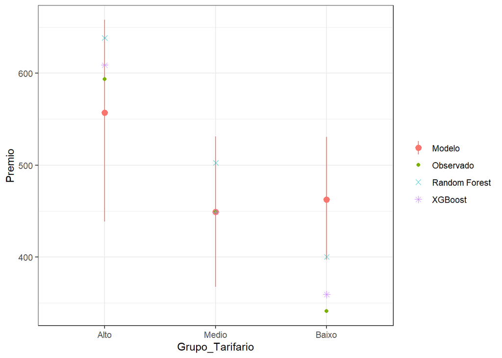

```r
# Gráfico com todos os resultados

comp$Grupo_Tarifario <- factor(comp$Grupo_Tarifario, levels = c("Alto", "Medio", "Baixo"))

ggplot(comp %>% cbind(IC95tot)) +
  theme_bw() +
  labs(colour = "", y = "Premio") +
  geom_pointrange(aes(x = Grupo_Tarifario, y = Esperado_Mod, ymin = `lower95`, ymax = `upper95`, color = "Modelo")) +
  geom_point(aes(x = Grupo_Tarifario, y = Razao, color = "Observado")) +
  geom_point(aes(x = Grupo_Tarifario, y = Esperado_RF, color = "Random Forest"), shape = 4, size = 2) +
  geom_point(aes(x = Grupo_Tarifario, y = Esperado_XGB, color = "XGBoost"), shape = 8, size = 2)
```

```r
### metrica de comparação dos modelos

# resíduo
tab_RES <- comp %>% mutate(RES_modelo = Razao - Esperado_Mod,
                RES_RF = Razao - Esperado_RF,
                RES_XGB = Razao - Esperado_XGB) %>%
  select(Grupo_Tarifario, Ano, RES_modelo, RES_RF, RES_XGB)
tab_RES
```

```
## # A tibble: 3 × 5
##   Grupo_Tarifario   Ano RES_modelo RES_RF RES_XGB
##   <fct>           <int>      <dbl>  <dbl>   <dbl>
## 1 Alto             2020     36.6    -44.8 -15.2
## 2 Medio            2020     -0.119  -53.4   0.132
## 3 Baixo            2020   -122.     -59.3 -18.2
```

```r
### RMSE (raiz do erro quadratico medio)
Tab_RMSE <- comp %>% mutate(RMSE_modelo = (Razao - Esperado_Mod)^2,
                RMSE_RF = (Razao - Esperado_RF)^2,
                RMSE_XGB = (Razao - Esperado_XGB)^2) %>%
  select(RMSE_modelo, RMSE_RF, RMSE_XGB) %>% colMeans() %>% sqrt()
Tab_RMSE
```

```
## RMSE_modelo     RMSE_RF    RMSE_XGB
##    73.29114    52.80741    13.69391
```

Definições:

Random Forest (Floresta Aleatória) é um algoritmo de aprendizado de máquina supervisionado utilizado tanto para tarefas de classificação quanto de regressão. Ele opera construindo múltiplas árvores de decisão durante o treinamento e, para realizar previsões, combina os resultados dessas árvores. No caso de classificação, a previsão final é determinada pela classe mais votada entre as árvores, para regressão, é calculada a média das previsões individuais.

XGBoost (eXtreme Gradient Boosting) é uma biblioteca de aprendizado de máquina de código aberto, amplamente utilizada para tarefas de classificação e regressão. Ele implementa uma versão otimizada do algoritmo de gradient boosting, que combina múltiplos modelos fracos, como árvores de decisão, para formar um modelo preditivo mais robusto e preciso.

O erro quadrático médio foi maior para os modelos de Bullman-Straub e Random Forest e menor para o XGboost. Os valores podem ser observados na Tab_RMSE.